# Intro to KidneyMarkerGenes Data Package

Aedin Culhane

September 18, 2018

# Clarke et al,. Kidney Marker Genes

In 2018 Clarke et presented a paper on bioRxiv

Jevin Z Clark, Lihe Chen, Chung-Lin Chou, Hyun Jun Jung, Mark A Knepper. Cell-Type Selective Markers Represented in Whole-Kidney RNA-Seq Data bioRxiv 348615; doi: https://doi.org/10.1101/348615

In this paper they describe several tables of marker gene for different normal kidney cell types

https://www.biorxiv.org/content/early/2018/06/15/348615

Brief Method: Kidneys were removed from 5 week male mice and immediately placed in ice-cold PBS. cDNA libraries were constructed for paired-end sequencing and sequenced on Illumina HiSeq3000 platform. Reads were mapped to mouse Ensembl Genome by STAR and transcript abundances were calculated in the units of transcripts per million (TPM) using RSEM (https://github.com/deweylab/RSEM).  
The supplementary data source provided mean TPM values for cell type selective markers expressed in mouse whole kidney samples. The number of replicates is n=3.

I downloaded the supplementary files

```r
library(KidneyMarkerGenes)
data(clarkeGenes)
clarkeGenes[1:2,]
```

```
##   Marker Gene Symbol                           Annotation Whole Kidney TPM
## 1              Acer2                alkaline ceramidase 2         9.356667
## 2              Acta2 actin, alpha 2, smooth muscle, aorta        40.520000
##   Rank                       Cell Type HGNC.symbol  Gene.stable.ID
## 1 7791 Collecting Duct Principal Cells       ACER2 ENSG00000177076
## 2 3418                   Myofibroblast       ACTA2 ENSG00000107796
```

Extract the gene lists from the supplementary file as Gene Symbols or EnsEMBL ids, as matrix or list. Either keep NA, or convert NA to zero

```r
clarkeGenesSigs(id= "Symbol",matrix=TRUE)[1:4,1:4]
```

```
##         B-lymphocytes B-lymphocytes (follicular) B-lymphocytes (memory)
##                    NA                         NA             0.06666667
## ACER2              NA                         NA                     NA
## ACTA2              NA                         NA                     NA
## ADAMTS5            NA                         NA                     NA
##         Basophil
##               NA
## ACER2         NA
## ACTA2         NA
## ADAMTS5       NA
```

```r
head(clarkeGenesSigs(id= "Ensembl",matrix=FALSE))
```

```
## $`B-lymphocytes`
## ENSG00000007312 ENSG00000105369 ENSG00000177455
##       1.0800000       0.3100000       0.1466667
##
## $`B-lymphocytes (follicular)`
## ENSG00000004468 ENSG00000012124 ENSG00000081237 ENSG00000104921
##      8.45666667      0.16000000      3.32666667      0.03333333
## ENSG00000196092
##      0.00000000
##
## $`B-lymphocytes (memory)`
## ENSG00000004468 ENSG00000066294 ENSG00000081237 ENSG00000114013
##      8.45666667      0.51333333      3.32666667      1.98000000
## ENSG00000121594 ENSG00000135318 ENSG00000142539 ENSG00000196092
##      0.00000000    101.18000000      0.06666667      0.00000000
## ENSG00000269404
##      0.06666667
##
## $Basophil
## ENSG00000026508 ENSG00000110848 ENSG00000183625 ENSG00000185291
##       0.4400000       0.2166667       0.0000000       0.4466667
##
## $`Collecting Duct Principal Cells`
## ENSG00000107485 ENSG00000117472 ENSG00000126895 ENSG00000131981
##        6.266667       55.463333       29.340000       78.603333
## ENSG00000148344 ENSG00000150201 ENSG00000151715 ENSG00000157240
##       26.313333      158.823333       46.473333       17.806667
## ENSG00000159167 ENSG00000165272 ENSG00000167580 ENSG00000171885
##        3.293333      139.793333      464.080000       13.166667
## ENSG00000177076
##        9.356667
##
## $`Connecting Tubule`
## ENSG00000035720 ENSG00000104327 ENSG00000115009 ENSG00000127412
##      2.75000000    316.12333333      0.01666667      8.19333333
## ENSG00000182118
##      0.85666667
```

Each gene in the list as a weight (TPM in normal kidney), visualize these weights

```r
sigsSym<-clarkeGenesSigs(id= "Symbol",matrix=TRUE,convertNA=TRUE)
```

Use complex heatmap to visualize the TPM of each gene in each cell type

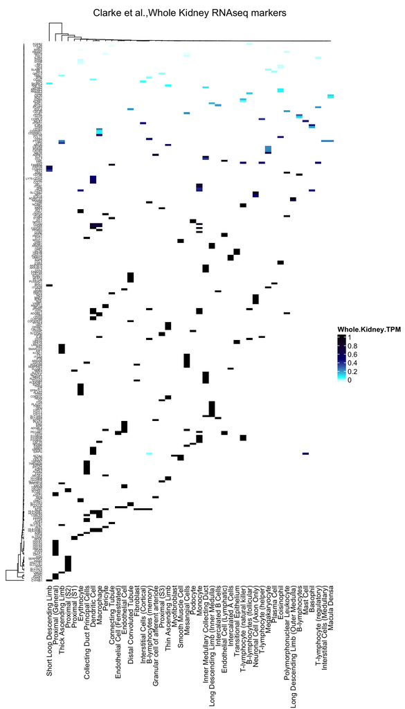

```r
require(circlize)
require(ComplexHeatmap)
ComplexHeatmap::Heatmap(excludeZeroSumRowCol(sigsSym),col = colorRamp2(c(0, 0.1, .5,1), c("white", "cyan", "navy", "black")) ,  clustering_method_columns = "ward.D2",  clustering_method_rows = "ward.D2" , row_names_side = "left", column_names_gp = gpar(fontsize = 10), row_names_gp = gpar(fontsize = 4),
    column_title = 'Clarke et al.,Whole Kidney RNAseq markers', heatmap_legend_param = list(title = "Whole.Kidney.TPM"))
```